# RiboTrack

2020-06-30

## Input Data

- Genomes:
  - PAO1;
  - PA14;
- Genomic features:
- tRNA relative concentrations (three replicates)

## Building & installing genomes

Genomes built using `BSgenome` library functionality from *PAO1* & *PA14* fasta files downloaded from NCBI.

```r
require(Biostrings)
require(BSgenome)

# P.aeruginosa PA14

forgeBSgenomeDataPkg('../src/PA14/seed.txt')

# installation from cl (tested on Ubuntu 18.04)
system('R CMD build BSgenome.Paeruginosa.NCBI.ASM1462v1')
system('R CMD check BSgenome.Paeruginosa.NCBI.ASM1462v1_1.0.0.tar.gz')
system('R CMD INSTALL BSgenome.Paeruginosa.NCBI.ASM1462v1_1.0.0.tar.gz')
```

Check if genomes are installed:

```r
BSgenome::installed.genomes()
```

```
## [1] "BSgenome.Ecoli.NCBI.20080805"        "BSgenome.Paeruginosa.NCBI.ASM1462v1"
## [3] "BSgenome.Paeruginosa.NCBI.ASM676v1"
```

## Loading genomes (PAO1)

```r
suppressPackageStartupMessages(library(BSgenome.Paeruginosa.NCBI.ASM676v1))

gnm_pao1 <- BSgenome.Paeruginosa.NCBI.ASM676v1
gnm_pao1
```

```
## P. aeruginosa PA01 genome:
## # organism: Pseudomonas aeruginosa (P. aeruginosa PAO1) (P. aeruginosa PA01)
## # provider: NCBI
## # provider version: ASM676v1
## # release date: 2006-07-07
## # release name: Pseudomonas aeruginosa PAO1 (g-proteobacteria)
## # 1 sequences:
## #   AE004091.2
## # (use 'seqnames()' to see all the sequence names, use the '$' or '[[' operator
## # to access a given sequence)
```

## Loading genomes (PA14)

```r
suppressPackageStartupMessages(library(BSgenome.Paeruginosa.NCBI.ASM1462v1))

gnm_pa14 <- BSgenome.Paeruginosa.NCBI.ASM1462v1
gnm_pa14
```

```
## P. aeruginosa PA14 genome:
## # organism: Pseudomonas aeruginosa (P. aeruginosa PA14)
## # provider: NCBI
## # provider version: ASM1462v1
## # release date: 2013-10-06
## # release name: Pseudomonas aeruginosa UCBPP-PA14 (g-proteobacteria)
## # 1 sequences:
## #   CP000438.1
## # (use 'seqnames()' to see all the sequence names, use the '$' or '[[' operator
## # to access a given sequence)
```

## Genomic features

To have an access to transcript-related features, and map *CDS*s of *PAO1* and *PA14* to their genomes, we built two relevant *TxDb* objects, using `GenomicFeatures` library:

```r
suppressPackageStartupMessages(library(GenomicFeatures))

txdb_pao1 <- loadDb('./dat/gnm/sql/TxDb.Paeruginosa.ASM676v1.sqlite')
txdb_pa14 <- loadDb('./dat/gnm/sql/TxDb.Paeruginosa.ASM1462v1.sqlite')

txdb_pa14
```

```
## TxDb object:
## # Db type: TxDb
## # Supporting package: GenomicFeatures
## # Data source: NCBI, Pseudomonas aeruginosa PA14, assembly ASM1462v1
## # Organism: Pseudomonas aeruginosa
## # Taxonomy ID: 287
## # miRBase build ID: NA
## # Genome: NA
## # Nb of transcripts: 5964
## # Db created by: GenomicFeatures package from Bioconductor
## # Creation time: 2020-06-22 20:01:40 +0200 (Mon, 22 Jun 2020)
## # GenomicFeatures version at creation time: 1.40.0
## # RSQLite version at creation time: 2.2.0
## # DBSCHEMAVERSION: 1.2
```

## TxDb objects

> The GenomicFeatures package uses TxDb objects to store transcript metadata. This class maps the 5’ and 3’ untranslated regions (UTRs), protein coding sequences (CDSs) and exons for a set of mRNA transcripts to their associated genome. TxDb objects have numerous accessors functions to allow such features to be retrieved individually or grouped together in a way that reflects the underlying biology.

> All TxDb objects are backed by a SQLite database that manages genomic locations and the relationships between pre-processed mRNA transcripts, exons, protein coding sequences, and their related gene identifiers

*(TxDb documentation)*

## NB: Synteny

We can align PA01 and PA14 genomes using `DECIFER` library:

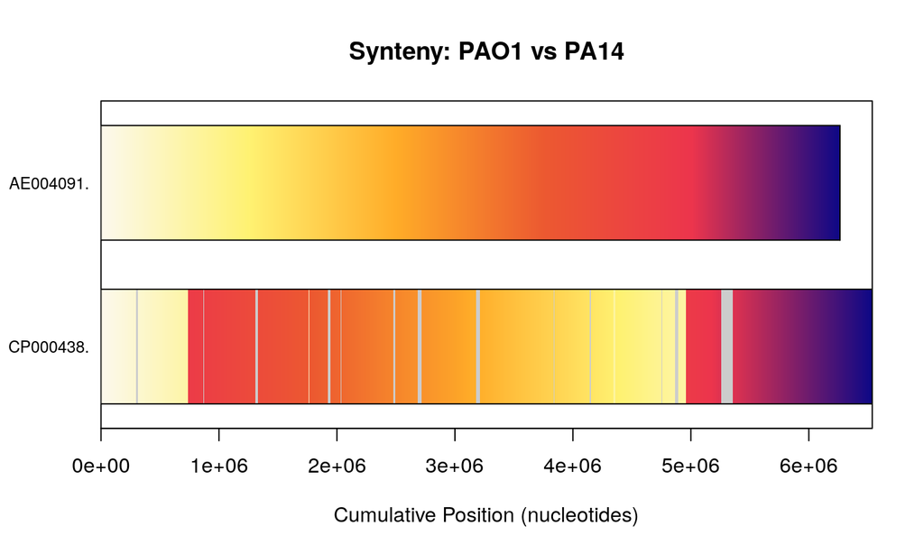

## NB: Synteny

With `SynExtend` package we can link relevant genes from two genomes, based on alignment coverage:

Linked pairs of genes between PAO1 and PA14 (ranges are shown for PA14)

| TotalCoverage | MaxCoverage | MinCoverage | NormDeltaStart | NormDeltaStop | NormGeneDiff | ExactMatch | gn_01 | gn_02 |
| --- | --- | --- | --- | --- | --- | --- | --- | --- |
| 0.9734628 | 0.9734628 | 0.9734628 | 0 | 0 | 0 | 1504 | AAG03391.1 | ABJ14957.1 |
| 0.9918478 | 0.9918478 | 0.9918478 | 0 | 0 | 0 | 1095 | AAG03392.1 | ABJ14958.1 |
| 0.9927928 | 0.9927928 | 0.9927928 | 0 | 0 | 0 | 1102 | AAG03393.1 | ABJ14959.1 |
| 0.9884345 | 0.9884345 | 0.9884345 | 0 | 0 | 0 | 2393 | AAG03394.1 | ABJ14960.1 |
| 0.9935401 | 0.9935401 | 0.9935401 | 0 | 0 | 0 | 769 | AAG03395.1 | ABJ14961.1 |
| 0.9962756 | 0.9962756 | 0.9962756 | 0 | 0 | 0 | 535 | AAG03396.1 | ABJ14962.1 |

5438 more records

## NB: Synteny

With these tables we can find e.g. identical genes:

Identical genes for PAO1 and PA14 (ranges are shown for PA14)

| Start | Stop | Type | ID | Product |
| --- | --- | --- | --- | --- |
| 15208 | 15474 | CDS | ABJ14968.1 | hypothetical protein |
| 40211 | 40426 | CDS | ABJ14995.1 | conserved hypothetical protein |
| 40610 | 40837 | CDS | ABJ14996.1 | conserved hypothetical protein |
| 59735 | 60088 | CDS | ABJ15004.1 | putative lipoprotein |
| 71678 | 71911 | CDS | ABJ15017.1 | conserved hypothetical protein |
| 78396 | 78671 | CDS | ABJ15025.1 | putative nucleic-acid-binding protein |

248 more records

## Extracting CDS ranges from PA14 TxDb

```
## GRanges object with 5892 ranges and 1 metadata column:
##                seqnames          ranges strand |    cds_id
##                   <Rle>       <IRanges>  <Rle> | <integer>
##   ABJ14957.1 CP000438.1        483-2027      + |         1
##   ABJ14958.1 CP000438.1       2056-3159      + |         2
##   ABJ14959.1 CP000438.1       3169-4278      + |         3
##   ABJ14960.1 CP000438.1       4275-6695      + |         4
##   ABJ14963.1 CP000438.1      8671-10377      + |         5
##          ...        ...             ...    ... .       ...
##   ABJ14952.1 CP000438.1 6530561-6532453      - |      5888
##   ABJ14953.1 CP000438.1 6532927-6533310      - |      5889
##   ABJ14954.1 CP000438.1 6533634-6535001      - |      5890
##   ABJ14955.1 CP000438.1 6535072-6536808      - |      5891
##   ABJ14956.1 CP000438.1 6537049-6537456      - |      5892
##   -------
##   seqinfo: 1 sequence (1 circular) from an unspecified genome; no seqlengths
```

## Extracting nucleotide sequence using CDS ranges and PA14 genome

```r
dna_pa14 <- getSeq(gnm_pa14, cds_pa14)
print(dna_pa14)
```

```
## DNAStringSet object of length 5892:
##        width seq                                            names
##    [1]  1545 GTGTCCGTGGAACTTTGGCAGC...CTGCGTACCCTGACAACCTGA ABJ14957.1
##    [2]  1104 ATGCATTTCACCATTCAACGCG...GTCATGCCGATGCGCCTCTAA ABJ14958.1
##    [3]  1110 ATGTCCCTGACCCGCGTTTCGG...ACCATCGGGAGTGAAGCATGA ABJ14959.1
##    [4]  2421 ATGAGCGAGAACAACACGTACG...GTGTCGAACCTGGACGTGTGA ABJ14960.1
##    [5]  1707 GTGAAACGCCTGAAAAAGACAC...GAGTATCTGAAGGTCCTGTAG ABJ14963.1
##    ...   ... ...
## [5888]  1893 GTGGATTTCCCTACCCGTTTTG...CAACTGGAGCAGAGCGCTTGA ABJ14952.1
## [5889]   384 GTGCACGCAAGACAACCCGGTA...CTGGAAAGCGGCAACGACTGA ABJ14953.1
## [5890]  1368 ATGCAAGCCGCCACCGAAACCA...AGTTTCTGCATCGGCAAGTAA ABJ14954.1
## [5891]  1737 ATGGACATTCAACGCTCGATTC...GCAGCCGCGAAGACCGCCTGA ABJ14955.1
## [5892]   408 GTGGTGAGTCGGGACTTCGACC...GCCGACGGTACTCATGCATAG ABJ14956.1
```

## Extracting codons for each PA14 CDS

```r
library(parallel)

triplets <- function(x) {
  unlist(strsplit(toString(x), '(?<=.{3})', perl = TRUE), use.names = F)
}

ncores <- detectCores()
cl     <- makeCluster(ncores)

#cdn_pao1 <- parLapply(cl, dna_pao1, triplets)
cdn_pa14 <- parLapply(cl, dna_pa14, triplets)

stopCluster(cl)
```

```
## List of 5
##  $ ABJ14957.1: chr [1:515] "GTG" "TCC" "GTG" "GAA" ...
##  $ ABJ14958.1: chr [1:368] "ATG" "CAT" "TTC" "ACC" ...
##  $ ABJ14959.1: chr [1:370] "ATG" "TCC" "CTG" "ACC" ...
##  $ ABJ14960.1: chr [1:807] "ATG" "AGC" "GAG" "AAC" ...
##  $ ABJ14963.1: chr [1:569] "GTG" "AAA" "CGC" "CTG" ...
```

5887 more records

## PA14 relative tRNA concentrations (raw data)

Relative tRNA concentrations (PA14 vs PAO1), raw

| probe | anticodon | codon | freq | sd |
| --- | --- | --- | --- | --- |
| PaeARGACG | Arg-ACG | Arg-CGT/C/G | 1.244328 | 0.2219052 |
| PaeARGACG2 | Arg-ACG-2 | Arg-CGT/C/G | 2.083219 | 0.0133548 |
| PaeARGCCG | Arg-CCG | Arg-CGC/T | 1.276256 | 0.2372632 |
| PaeARGCCG214 | Arg-CCG-214 | Arg-CGC/T | 1.256060 | 0.1671407 |
| PaeARGCCT | Arg-CCU | Arg-AGG | 1.095603 | 0.1348163 |
| PaeARGTCT | Arg-UCU | Arg-AGA | 1.607101 | 0.1096068 |

With 38 more records

## PA14 relative tRNA concentrations (clean data)

Relative tRNA concentrations (PA14 vs PAO1), clean

| aa | codon | freq |
| --- | --- | --- |
| K | AAA | 1.359299 |
| N | AAC | 2.275652 |
| N | AAT | 2.275652 |
| T | ACA | 0.000000 |
| T | ACC | 1.577817 |
| T | ACG | 1.353397 |

With 38 more records

## Assigning tRNA concentrations to codons

Now we can assign relative PA14 tRNA concentrations to the respective position of codone for all CDS:

```r
cdn_freq_list_pa14  <- NumericList(sapply(cdn_pa14, function(codon) unlist(freq[codon], use.names = F)))
```

```
## Formal class 'CompressedNumericList' [package "IRanges"] with 5 slots
##   ..@ elementType    : chr "numeric"
##   ..@ elementMetadata: NULL
##   ..@ metadata       : list()
##   ..@ unlistData     : num [1:1942725] 1 1.49 1 1 1.06 ...
##   ..@ partitioning   :Formal class 'PartitioningByEnd' [package "IRanges"] with 5 slots
```

## RiboTrack class (class definition)

To make work with the data more comfortable, we create `RiboTrack` class, which contains general information about the strain, and named list of tRNA concentration at each position of the respective codone:

```r
setClass(
  'RiboTrack',
  representation(
    info  = 'character',
    freq  = 'CompressedNumericList'
    ),
  prototype(
    info  = NA_character_,
    freq  = NumericList()
  )
)
```

## RiboTrack methods

We can define several useful methods on the `RiboTrack` class, which makes it easier to process data as whole or work with subset of CDSs or single CDS (more methods will be added):

```
##  [1] -             [             *             /             +
##  [6] cumsum        info          names         plot          scale
## [11] smooth.spline spline
## see '?methods' for accessing help and source code
```

## Ribotrack methods (object creation)

```r
pa14 <- new('RiboTrack')
pa14@info <- 'P.aeruginosa, PA14'
pa14@freq <- cdn_freq_list_pa14
pa14
```

```
## An object of class "RiboTrack"
## Slot "info":
## [1] "P.aeruginosa, PA14"
##
## Slot "freq":
## NumericList of length 5892
## [["ABJ14957.1"]] 1 1.49183137634263 1 ... 0.971684718203384 0 1.57781665993547
## [["ABJ14958.1"]] 1.45175744745032 1.52059342495622 ... 1.44237952388199
## [["ABJ14959.1"]] 1.45175744745032 1.49183137634263 ... 1.02654662694648
## [["ABJ14960.1"]] 1.45175744745032 1.08699302708687 1 ... 0.976161893489229 1
## [["ABJ14963.1"]] 1 1.35929884179413 ... 1.01932082367236 0.971684718203384
## [["ABJ14966.1"]] 1.45175744745032 1.23938050992458 ... 1.47843267640469
## [["ABJ14967.1"]] 1 1 1.35929884179413 ... 1.12487591025257 1.17624178004838
## [["ABJ14968.1"]] 1.45175744745032 0.976161893489229 ... 1.02016025177701
## [["ABJ14969.1"]] 1.45175744745032 1.07624725179974 ... 1.02335343936174
## [["ABJ14976.1"]] 1.45175744745032 1.09560257709242 ... 1.48704024233963
## ...
## <5882 more elements>
```

## Ribotrack methods (select)

Select, using `[` notation by *index* or *CDC name*

```r
pa14[23]
```

```
## An object of class "RiboTrack"
## Slot "info":
## [1] "P.aeruginosa, PA14"
##
## Slot "freq":
## NumericList of length 1
## [["ABJ14997.1"]] 1 1.02335343936174 ... 1.22172797842537 1.22172797842537
```

```r
pa14['ABJ14997.1']
```

```
## An object of class "RiboTrack"
## Slot "info":
## [1] "P.aeruginosa, PA14"
##
## Slot "freq":
## NumericList of length 1
## [["ABJ14997.1"]] 1 1.02335343936174 ... 1.22172797842537 1.22172797842537
```

## Ribotrack methods (arithmetics)

```r
pa14[c(17, 23)] - 1
```

```
## An object of class "RiboTrack"
## Slot "info":
## [1] "P.aeruginosa, PA14"
##
## Slot "freq":
## NumericList of length 2
## [["ABJ14984.1"]] 0 0 0.464965599884775 ... 0.02654662694648 0.48704024233963
## [["ABJ14997.1"]] 0 0.0233534393617449 ... 0.22172797842537 0.22172797842537
```

```r
1 / pa14[c(17, 23)]
```

```
## An object of class "RiboTrack"
## Slot "info":
## [1] "P.aeruginosa, PA14"
##
## Slot "freq":
## NumericList of length 2
## [["ABJ14984.1"]] 1 1 0.682609885227785 ... 0.974139872218523 0.672476757203728
## [["ABJ14997.1"]] 1 0.977179497851387 ... 0.81851280944622 0.81851280944622
```

(`+`, `*` are also implemented)

## RiboTrac methods (scale)

Scale and|or center relative tRNA concentrations for all CDSs or for a subset of CDSs:

```r
# Not scaled
pa14[17]
```

```
## An object of class "RiboTrack"
## Slot "info":
## [1] "P.aeruginosa, PA14"
##
## Slot "freq":
## NumericList of length 1
## [["ABJ14984.1"]] 1 1 1.46496559988478 ... 1.02654662694648 1.48704024233963
```

```r
# Scaled and centered
scale(pa14[17], center = TRUE, scale = TRUE)
```

```
## An object of class "RiboTrack"
## Slot "info":
## [1] "P.aeruginosa, PA14"
##
## Slot "freq":
## NumericList of length 1
## [[1]] -0.604970651410324 -0.604970651410324 ... 1.3417692539168
```

## RiboTrack methods (cumulative summ)

```r
cumsum(pa14[c(17, 23)] - 1)
```

```
## An object of class "RiboTrack"
## Slot "info":
## [1] "P.aeruginosa, PA14"
##
## Slot "freq":
## NumericList of length 2
## [["ABJ14984.1"]] 0 0 0.464965599884775 ... 29.7835728852766 30.2706131276163
## [["ABJ14997.1"]] 0 0.0233534393617449 ... 138.259703358266 138.481431336691
```

## RiboTrack methods (plot)

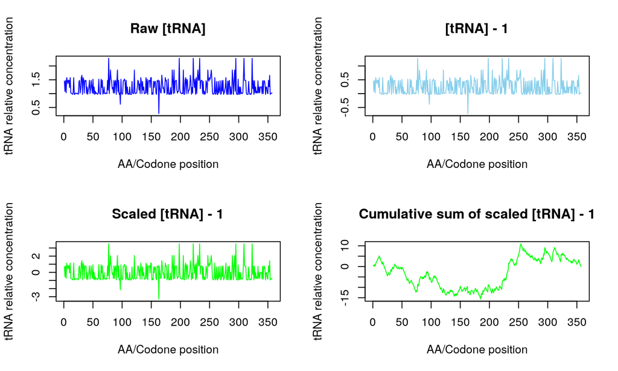